# Predicting Car Fuel Efficiency using Multiple Linear Regression

# 7.0 RESIDUAL ANALYSIS

We checked the fitted values and residuals of the first model to assess the goodness of fit. The scatter plot of fitted values against residuals was used to identify any remaining patterns or deviations. Additionally, we examined the normality of residuals using a `quantile-quantile (QQ) plot.`

```r
model_cars$fitted.values
```

```
##        1        2        3        4        5        6        7        8
## 21.33650 20.51907 26.55377 19.42916 16.89262 18.64379 16.47590 23.76489
##        9       10       11       12       13       14       15       16
## 23.89311 18.70790 18.70790 14.87309 15.96300 15.80272 11.09046 10.53269
##       17       18       19       20       21       22       23       24
## 10.78593 26.93844 28.81373 28.10849 26.08896 16.63618 16.90865 15.61038
##       25       26       27       28       29       30       31       32
## 15.59435 27.78793 27.13078 29.14070 17.75814 20.85566 16.47590 25.07919
```

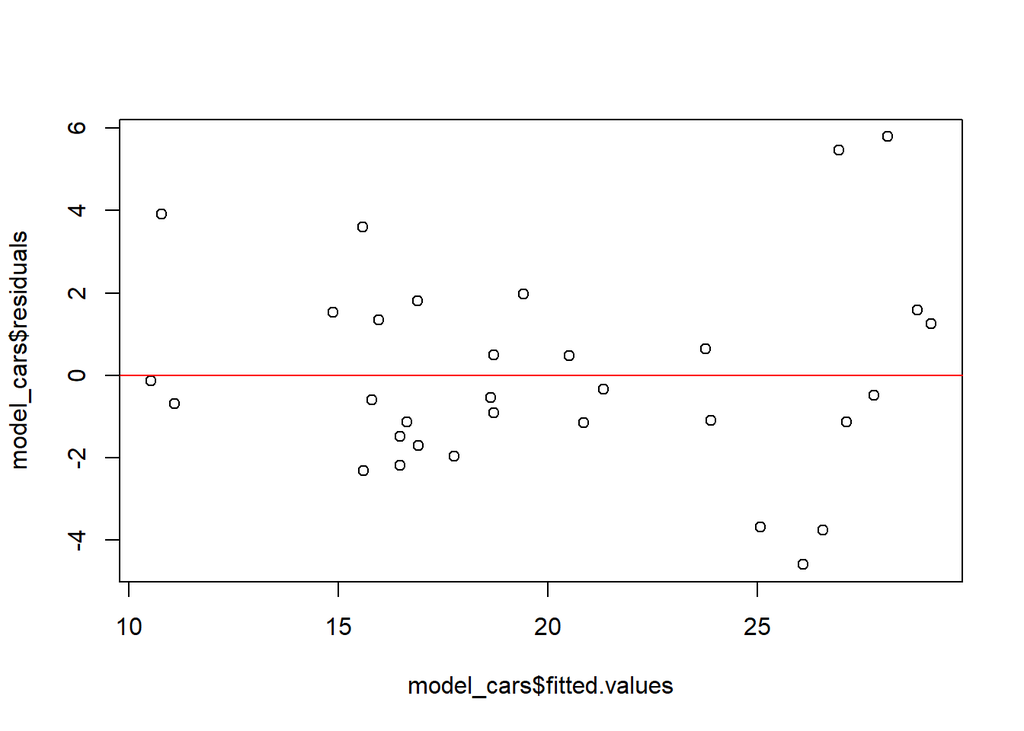

```r
plot(model_cars$fitted.values, model_cars$residuals)
abline(0, 0, col = "red")
```

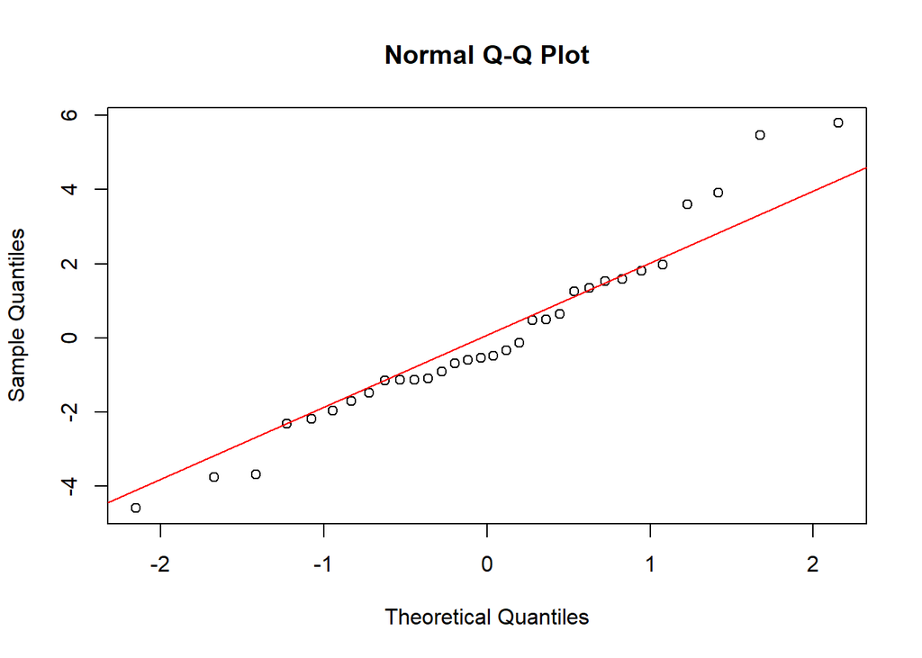

```r
qqnorm(model_cars$residuals)
qqline(model_cars$residuals, col = "red")
```

```r
model_cars_only_wt <- lm(mtcars$mpg ~ mtcars$wt)
```

# 8.0 MODEL SELECTION

```r
AIC(model_cars)
```

```
## [1] 156.6223
```

```r
AIC(model_cars_only_wt)
```

```
## [1] 166.0294
```

# 9.0 CONCLUSION

It’s essential to note that this analysis is based on the available dataset and may not be applicable to all car models. Further studies and additional variables may be necessary for more comprehensive predictions and insights.

# 10.0 REFERENCES

Wickham, H., & Grolemund, G. (2017). R for Data Science: Import, Tidy, Transform, Visualize, and Model Data. O’Reilly Media.